# Tarea 4

# Métodos Supervisados con Python

Pregunta 1: [35 puntos] En este ejercicio usaremos los datos (voces.csv). Se trata de un problema de reconocimiento de g´enero mediante el an´alisis de la voz y el habla. Esta base de datos fue creada para identificar una voz como masculina o femenina, bas´andose en las propiedades ac´usticas de la voz y el habla. El conjunto de datos consta de 3.168 muestras de voz grabadas, recogidas de hablantes masculinos y femeninos. Realice lo siguiente:

1. Cargue la tabla de datos voces.csv en Python

```python
import os
import pandas as pd
import numpy  as np
import matplotlib.pyplot as plt
from sklearn.model_selection import train_test_split
from sklearn.svm import SVC
from sklearn.metrics import confusion_matrix
from pandas import DataFrame
from matplotlib import colors as mcolors
import seaborn as sns


pasada = os.getcwd()
os.chdir("C:/Users/rzamoram/OneDrive - Intel Corporation/Documents/Machine Learning/Métodos Supervisados con Python/Clase 01")
print(os.getcwd())
datos = pd.read_csv('voces.csv',delimiter=',',decimal=".")
```

```
C:\Users\rzamoram\OneDrive - Intel Corporation\Documents\Machine Learning\Métodos Supervisados con Python\Clase 01
```

```python
print(datos.shape)
print(datos.head())
print(datos.info())

datos.describe(include = np.number)
```

```
(3168, 21)
   meanfreq        sd    median       Q25       Q75       IQR       skew  \
0  0.059781  0.064241  0.032027  0.015071  0.090193  0.075122  12.863462
1  0.066009  0.067310  0.040229  0.019414  0.092666  0.073252  22.423285
2  0.077316  0.083829  0.036718  0.008701  0.131908  0.123207  30.757155
3  0.151228  0.072111  0.158011  0.096582  0.207955  0.111374   1.232831
4  0.135120  0.079146  0.124656  0.078720  0.206045  0.127325   1.101174

          kurt    sp.ent       sfm  ...  centroid   meanfun    minfun  \
0   274.402906  0.893369  0.491918  ...  0.059781  0.084279  0.015702
1   634.613855  0.892193  0.513724  ...  0.066009  0.107937  0.015826
2  1024.927705  0.846389  0.478905  ...  0.077316  0.098706  0.015656
3     4.177296  0.963322  0.727232  ...  0.151228  0.088965  0.017798
4     4.333713  0.971955  0.783568  ...  0.135120  0.106398  0.016931

```

[output cut: 37 more lines]

|  | meanfreq | sd | median | Q25 | Q75 | IQR | skew | kurt | sp.ent | sfm | mode | centroid | meanfun | minfun | maxfun | meandom | mindom | maxdom | dfrange | modindx |
| --- | --- | --- | --- | --- | --- | --- | --- | --- | --- | --- | --- | --- | --- | --- | --- | --- | --- | --- | --- | --- |
| count | 3168.000000 | 3168.000000 | 3168.000000 | 3168.000000 | 3168.000000 | 3168.000000 | 3168.000000 | 3168.000000 | 3168.000000 | 3168.000000 | 3168.000000 | 3168.000000 | 3168.000000 | 3168.000000 | 3168.000000 | 3168.000000 | 3168.000000 | 3168.000000 | 3168.000000 | 3168.000000 |
| mean | 0.180907 | 0.057126 | 0.185621 | 0.140456 | 0.224765 | 0.084309 | 3.140168 | 36.568461 | 0.895127 | 0.408216 | 0.165282 | 0.180907 | 0.142807 | 0.036802 | 0.258842 | 0.829211 | 0.052647 | 5.047277 | 4.994630 | 0.173752 |
| std | 0.029918 | 0.016652 | 0.036360 | 0.048680 | 0.023639 | 0.042783 | 4.240529 | 134.928661 | 0.044980 | 0.177521 | 0.077203 | 0.029918 | 0.032304 | 0.019220 | 0.030077 | 0.525205 | 0.063299 | 3.521157 | 3.520039 | 0.119454 |
| min | 0.039363 | 0.018363 | 0.010975 | 0.000229 | 0.042946 | 0.014558 | 0.141735 | 2.068455 | 0.738651 | 0.036876 | 0.000000 | 0.039363 | 0.055565 | 0.009775 | 0.103093 | 0.007812 | 0.004883 | 0.007812 | 0.000000 | 0.000000 |
| 25% | 0.163662 | 0.041954 | 0.169593 | 0.111087 | 0.208747 | 0.042560 | 1.649569 | 5.669547 | 0.861811 | 0.258041 | 0.118016 | 0.163662 | 0.116998 | 0.018223 | 0.253968 | 0.419828 | 0.007812 | 2.070312 | 2.044922 | 0.099766 |
| 50% | 0.184838 | 0.059155 | 0.190032 | 0.140286 | 0.225684 | 0.094280 | 2.197101 | 8.318463 | 0.901767 | 0.396335 | 0.186599 | 0.184838 | 0.140519 | 0.046110 | 0.271186 | 0.765795 | 0.023438 | 4.992188 | 4.945312 | 0.139357 |
| 75% | 0.199146 | 0.067020 | 0.210618 | 0.175939 | 0.243660 | 0.114175 | 2.931694 | 13.648905 | 0.928713 | 0.533676 | 0.221104 | 0.199146 | 0.169581 | 0.047904 | 0.277457 | 1.177166 | 0.070312 | 7.007812 | 6.992188 | 0.209183 |
| max | 0.251124 | 0.115273 | 0.261224 | 0.247347 | 0.273469 | 0.252225 | 34.725453 | 1309.612887 | 0.981997 | 0.842936 | 0.280000 | 0.251124 | 0.237636 | 0.204082 | 0.279114 | 2.957682 | 0.458984 | 21.867188 | 21.843750 | 0.932374 |

```python
def distribucion_variable_predecir(data:DataFrame,variable_predict:str):
    colors = list(dict(**mcolors.CSS4_COLORS))
    df = pd.crosstab(index=data[variable_predict],columns="valor") / data[variable_predict].count()
    fig = plt.figure(figsize=(10,9))
    g = fig.add_subplot(111)
    countv = 0
    titulo = "Distribución de la variable %s" % variable_predict
    for i in range(df.shape[0]):
        g.barh(1,df.iloc[i],left = countv, align='center',color=colors[11+i],label= df.iloc[i].name)
        countv = countv + df.iloc[i]
    vals = g.get_xticks()
    g.set_xlim(0,1)
    g.set_yticklabels("")
    g.set_title(titulo)
    g.set_ylabel(variable_predict)
    g.set_xticklabels(['{:.0%}'.format(x) for x in vals])
    countv = 0
    for v in df.iloc[:,0]:
        g.text(np.mean([countv,countv+v]) - 0.03, 1 , '{:.1%}'.format(v), color='black', fontweight='bold')
        countv = countv + v
    g.legend(loc='upper center', bbox_to_anchor=(1.08, 1), shadow=True, ncol=1)
```

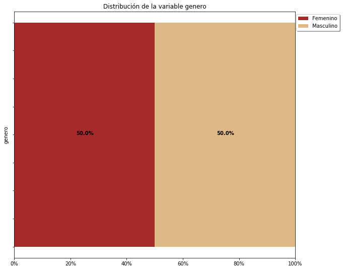

```python
distribucion_variable_predecir(datos,"genero")
```

Problema equilibrado

1. Use M´aquinas de Soporte Vectorial en Python (con los par´ametros por defecto) para generar un modelo predictivo para la tabla voces.csv usando el 80 % de los datos para la tabla aprendizaje y un 20 % para la tabla testing, luego calcule para los datos de testing la matriz de confusi´on, la precisi´on global y la precisi´on para cada una de las dos categor´ıas. ¿Son buenos los resultados? Explique.

```python
def indices_general(MC, nombres = None):
    precision_global = np.sum(MC.diagonal()) / np.sum(MC)
    error_global = 1 - precision_global
    precision_categoria  = pd.DataFrame(MC.diagonal()/np.sum(MC,axis = 1)).T
    if nombres!=None:
        precision_categoria.columns = nombres
    return {"Matriz de Confusión":MC,
            "Precisión Global":precision_global,
            "Error Global":error_global,
            "Precisión por categoría":precision_categoria}

def poder_predictivo_categorica(data:DataFrame, var:str, variable_predict:str):
    df = pd.crosstab(index= data[var],columns=data[variable_predict])
    df = df.div(df.sum(axis=1),axis=0)
    titulo = "Distribución de la variable %s según la variable %s" % (var,variable_predict)
    g = df.plot(kind='barh',stacked=True,legend = True, figsize = (10,9), \
                xlim = (0,1),title = titulo, width = 0.8)
    vals = g.get_xticks()
    g.set_xticklabels(['{:.0%}'.format(x) for x in vals])
    g.legend(loc='upper center', bbox_to_anchor=(1.08, 1), shadow=True, ncol=1)
    for bars in g.containers:
        plt.setp(bars, width=.9)
    for i in range(df.shape[0]):
        countv = 0
        for v in df.iloc[i]:
            g.text(np.mean([countv,countv+v]) - 0.03, i , '{:.1%}'.format(v), color='black', fontweight='bold')
            countv = countv + v

def poder_predictivo_numerica(data:DataFrame, var:str, variable_predict:str):
    sns.FacetGrid(data, hue=variable_predict, height=6).map(sns.kdeplot, var, shade=True).add_legend()
```

```python
X = datos.iloc[:,:20]
print(X.head())
y = datos.iloc[:,20:21]
print(y.head())
X_train, X_test, y_train, y_test = train_test_split(X, y, train_size=0.8, random_state=0)
```

```
   meanfreq        sd    median       Q25       Q75       IQR       skew  \
0  0.059781  0.064241  0.032027  0.015071  0.090193  0.075122  12.863462
1  0.066009  0.067310  0.040229  0.019414  0.092666  0.073252  22.423285
2  0.077316  0.083829  0.036718  0.008701  0.131908  0.123207  30.757155
3  0.151228  0.072111  0.158011  0.096582  0.207955  0.111374   1.232831
4  0.135120  0.079146  0.124656  0.078720  0.206045  0.127325   1.101174

          kurt    sp.ent       sfm      mode  centroid   meanfun    minfun  \
0   274.402906  0.893369  0.491918  0.000000  0.059781  0.084279  0.015702
1   634.613855  0.892193  0.513724  0.000000  0.066009  0.107937  0.015826
2  1024.927705  0.846389  0.478905  0.000000  0.077316  0.098706  0.015656
3     4.177296  0.963322  0.727232  0.083878  0.151228  0.088965  0.017798
4     4.333713  0.971955  0.783568  0.104261  0.135120  0.106398  0.016931

     maxfun   meandom    mindom    maxdom   dfrange   modindx
0  0.275862  0.007812  0.007812  0.007812  0.000000  0.000000
1  0.250000  0.009014  0.007812  0.054688  0.046875  0.052632
2  0.271186  0.007990  0.007812  0.015625  0.007812  0.046512
3  0.250000  0.201497  0.007812  0.562500  0.554688  0.247119
4  0.266667  0.712812  0.007812  5.484375  5.476562  0.208274
      genero
0  Masculino
1  Masculino
2  Masculino
3  Masculino
4  Masculino
```

```python
instancia_svm = SVC()
print(instancia_svm)
```

```
SVC(C=1.0, break_ties=False, cache_size=200, class_weight=None, coef0=0.0,
    decision_function_shape='ovr', degree=3, gamma='scale', kernel='rbf',
    max_iter=-1, probability=False, random_state=None, shrinking=True,
    tol=0.001, verbose=False)
```

```python
instancia_svm.fit(X_train,y_train.iloc[:,0].values)
print("Las predicciones en Testing son: {}".format(instancia_svm.predict(X_test)))
```

[output not shown]

[output cut: 51 more lines]

[output not shown]

```python
prediccion = instancia_svm.predict(X_test)
MC = confusion_matrix(y_test, prediccion)
indices = indices_general(MC,list(np.unique(y)))
for k in indices:
    print("\n%s:\n%s"%(k,str(indices[k])))
```

```
Matriz de Confusión:
[[171 130]
 [ 73 260]]

Precisión Global:
0.6798107255520505

Error Global:
0.32018927444794953

Precisión por categoría:
   Femenino  Masculino
0  0.568106   0.780781
```

En este caso el problema parece tener una precision global de 0.6798107255520505. En general, es dificil indicar si un modelo es bueno o malo, el modelo presenta muchos datos confundidos, pero predice mas de un 50% de los datos lo que en realidad muestra que el modelo funciona y dado que no es un modelo que parece tener conotaciones medicas de vida o muerte puede tomarse como valido.

1. Usando la funci´on programada en el ejercicio 1 de la tarea anterior, los datos voces.csv y los modelos generados arriba construya un DataFrame de manera que en cada una de las filas aparezca un modelo predictivo y en las columnas aparezcan los ´ındices Precisi´on Global, Error Global Precisi´on Positiva (PP), Precisi´on Negativa (PN), Falsos Positivos (FP), los Falsos Negativos (FN), la Asertividad Positiva (AP) y la Asertividad Negativa (AN). Compare con todos los medelos generados en las tareas anteriores ¿Cu´al de los modelos es mejor para estos datos?

```python
def indices_general_extra(MC, nombres = None):
    precision_global = np.sum(MC.diagonal()) / np.sum(MC)
    error_global = 1 - precision_global
    precision_categoria  = pd.DataFrame(MC.diagonal()/np.sum(MC,axis = 1)).T
    precision_positiva = MC[1][1]/(MC[1][1] + MC[1][0])
    precision_negativa = MC[0][0]/(MC[0][0] + MC[0][1])
    falsos_positivos = 1 - precision_negativa
    falsos_negativos = 1 - precision_positiva
    asertividad_positiva = MC[1][1]/(MC[0][1] + MC[1][1])
    asertividad_negativa = MC[0][0]/(MC[0][0] + MC[1][0])
    if nombres!=None:
        precision_categoria.columns = nombres
    return {"Matriz de Confusión":MC,
            "Precisión Global":precision_global,
            "Error Global":error_global,
            "Precisión por categoría":precision_categoria,
            "Precision Positiva (PP)": precision_positiva,
            "Precision Negativa (PN)":precision_negativa,
            "Falsos Positivos(FP)": falsos_positivos,
            "Falsos Negativos (FN)": falsos_negativos,
            "Asertividad Positiva (AP)": asertividad_positiva,
            "Asertividad Negativa (NP)": asertividad_negativa}
```

```python
indices = indices_general_extra(MC,list(np.unique(y)))
for k in indices:
    print("\n%s:\n%s"%(k,str(indices[k])))
```

```
Matriz de Confusión:
[[171 130]
 [ 73 260]]

Precisión Global:
0.6798107255520505

Error Global:
0.32018927444794953

Precisión por categoría:
   Femenino  Masculino
0  0.568106   0.780781

Precision Positiva (PP):
0.7807807807807807

Precision Negativa (PN):
0.5681063122923588

Falsos Positivos(FP):
0.43189368770764125

Falsos Negativos (FN):
0.21921921921921927

Asertividad Positiva (AP):
0.6666666666666666

Asertividad Negativa (NP):
0.7008196721311475
```

```python
A = np.matrix([[0.7413249211356467, 0.25867507886435326, 0.7717717717717718, 0.707641196013289, 0.292358803986711, 0.2282282282282282, 0.744927536231884, 0.7370242214532872],
               [0.9794952681388013, 0.02050473186119872, 0.975975975975976, 0.9833887043189369, 0.01661129568106312, 0.024024024024024038, 0.9848484848484849, 0.9736842105263158],
              [0.9605678233438486, 0.039432176656151396, 0.963963963963964, 0.9568106312292359, 0.04318936877076407, 0.036036036036036, 0.9610778443113772, 0.96],
              [0.944794952681388, 0.05520504731861198, 0.948948948948949, 0.9401993355481728, 0.05980066445182719, 0.05105105105105101, 0.9461077844311377, 0.9433333333333334],
              [0.9006309148264984, 0.09936908517350163, 0.9519519519519519, 0.8438538205980066, 0.15614617940199338, 0.048048048048048075, 0.8708791208791209, 0.9407407407407408],
              [0.9668769716088328, 0.03312302839116721, 0.960960960960961, 0.973421926910299, 0.02657807308970095, 0.03903903903903905, 0.975609756097561, 0.9575163398692811],
              [0.944794952681388, 0.05520504731861198, 0.948948948948949, 0.9401993355481728, 0.05980066445182719, 0.05105105105105101, 0.9461077844311377, 0.9433333333333334],
              [0.916403785488959, 0.08359621451104104, 0.987987987987988, 0.8372093023255814, 0.16279069767441856, 0.012012012012011963, 0.8703703703703703, 0.984375],
              [0.9810725552050473, 0.018927444794952675, 0.975975975975976, 0.9867109634551495, 0.013289036544850474, 0.024024024024024038, 0.9878419452887538, 0.9737704918032787],
              [0.9779179810725552, 0.02208201892744477, 0.9819819819819819, 0.973421926910299, 0.02657807308970095, 0.018018018018018056, 0.9761194029850746, 0.979933110367893],
              [0.9652996845425867, 0.034700315457413256, 0.987987987987988, 0.9401993355481728, 0.05980066445182719, 0.012012012012011963, 0.9481268011527377, 0.9860627177700348],
              [0.9542586750788643, 0.045741324921135695, 0.975975975975976, 0.9302325581395349, 0.06976744186046513, 0.024024024024024038, 0.9393063583815029, 0.9722222222222222],
              [0.9621451104100947, 0.03785488958990535, 0.9429429429429429, 0.9833887043189369, 0.01661129568106312, 0.0570570570570571, 0.9843260188087775, 0.9396825396825397],
              [0.9589905362776026, 0.04100946372239744, 0.987987987987988, 0.9269102990033222, 0.07308970099667778, 0.012012012012011963, 0.9373219373219374, 0.9858657243816255],
              [0.9810725552050473, 0.018927444794952675, 0.975975975975976, 0.9867109634551495, 0.013289036544850474, 0.024024024024024038, 0.9878419452887538, 0.9737704918032787],
              [0.9684542586750788, 0.03154574132492116, 0.975975975975976, 0.9601328903654485, 0.039867109634551534, 0.024024024024024038, 0.9643916913946587, 0.9730639730639731],
              [0.9574132492113565, 0.04258675078864349, 0.9669669669669669, 0.946843853820598, 0.05315614617940201, 0.033033033033033066, 0.9526627218934911, 0.9628378378378378],
              [0.9826498422712934, 0.017350157728706628, 0.9819819819819819, 0.9833887043189369, 0.01661129568106312, 0.018018018018018056, 0.9849397590361446, 0.9801324503311258],
              [0.9652996845425867, 0.034700315457413256, 0.96996996996997, 0.9601328903654485, 0.039867109634551534, 0.03003003003003002, 0.9641791044776119, 0.9665551839464883],
              [0.9637223974763407, 0.0362776025236593, 0.9819819819819819, 0.9435215946843853, 0.056478405315614655, 0.018018018018018056, 0.9505813953488372, 0.9793103448275862],
              [0.9779179810725552, 0.02208201892744477, 0.978978978978979, 0.9767441860465116, 0.023255813953488413, 0.02102102102102099, 0.978978978978979, 0.9767441860465116],
              [0.973186119873817, 0.02681388012618302, 0.972972972972973, 0.973421926910299, 0.02657807308970095, 0.027027027027026973, 0.9759036144578314, 0.9701986754966887],
              [0.9652996845425867, 0.034700315457413256, 0.987987987987988, 0.9401993355481728, 0.05980066445182719, 0.012012012012011963, 0.9481268011527377, 0.9860627177700348],
              [0.9779179810725552, 0.02208201892744477, 0.975975975975976, 0.9800664451827242, 0.019933554817275767, 0.024024024024024038, 0.9818731117824774, 0.9735973597359736],
              [0.9652996845425867, 0.034700315457413256, 0.963963963963964, 0.9667774086378738, 0.03322259136212624, 0.036036036036036, 0.9697885196374623, 0.9603960396039604],
              [0.9716088328075709, 0.028391167192429068, 0.975975975975976, 0.9667774086378738, 0.03322259136212624, 0.024024024024024038, 0.9701492537313433, 0.9732441471571907],
              [0.6798107255520505, 0.32018927444794953, 0.7807807807807807, 0.5681063122923588, 0.43189368770764125, 0.21921921921921927, 0.6666666666666666, 0.7008196721311475]])
mi_df = pd.DataFrame(A)
nombres_filas = ["K-vecinos todas variables","K-vecinos 6 variables","Arbol de Decision (default)","Arbol de Decision (criterion='entropy',max_depth=2)","Arbol de Decision (criterion='gini', splitter='random', max_depth=3)",
                 "Arbol de Decision 6 predictoras (default)","Arbol de Decision 6 predictoras (criterion='entropy',max_depth=2)","Arbol de Decision 6 predictoras (criterion='gini', splitter='random', max_depth=3)",
                 "Bosques", "XGBoosting", "ADA Boosting", "Bosques (n_estimators=7, max_depth=2, random_state=0) ", "XGBoosting(n_estimators=7, max_depth=2, random_state=0)", "ADA Boosting (n_estimators=7, random_state=0)",
                 "Bosques 6 predictoras (opcion 1)", "XGBoosting 6 predictoras (opcion 1)", "ADA Boosting 6 predictoras(opcion 1)",
                 "Bosques 6 predictoras (opcion 1)(n_estimators=700, max_depth=200, random_state=0)", "XGBoosting 6 predictoras (opcion 1)(n_estimators=700, max_depth=200, random_state=0)", "ADA Boosting 6 predictoras(opcion 1)(n_estimators=700, random_state=0)",
                 "Bosques 6 predictoras (opcion 2)", "XGBoosting 6 predictoras (opcion 2)", "ADA Boosting 6 predictoras(opcion 2)",
                 "Bosques 6 predictoras (opcion 2)(n_estimators=700, max_depth=200, random_state=0)", "XGBoosting 6 predictoras (opcion 2)(n_estimators=700, max_depth=200, random_state=0)", "ADA Boosting 6 predictoras(opcion 2)(n_estimators=700, random_state=0)", "SVM"]
nombres_columnas = ["Precisi´on Global","Error Global","Precisi´on Positiva (PP)", "Precisi´on Negativa (PN)", "Falsos Positivos (FP)", "Falsos Negativos (FN)", "Asertividad Positiva (AP)", "Asertividad Negativa (AN)"]
mi_df = pd.DataFrame(A, index = nombres_filas, columns = nombres_columnas )
mi_df
```

|  | Precisi´on Global | Error Global | Precisi´on Positiva (PP) | Precisi´on Negativa (PN) | Falsos Positivos (FP) | Falsos Negativos (FN) | Asertividad Positiva (AP) | Asertividad Negativa (AN) |
| --- | --- | --- | --- | --- | --- | --- | --- | --- |
| K-vecinos todas variables | 0.741325 | 0.258675 | 0.771772 | 0.707641 | 0.292359 | 0.228228 | 0.744928 | 0.737024 |
| K-vecinos 6 variables | 0.979495 | 0.020505 | 0.975976 | 0.983389 | 0.016611 | 0.024024 | 0.984848 | 0.973684 |
| Arbol de Decision (default) | 0.960568 | 0.039432 | 0.963964 | 0.956811 | 0.043189 | 0.036036 | 0.961078 | 0.960000 |
| Arbol de Decision (criterion='entropy',max_depth=2) | 0.944795 | 0.055205 | 0.948949 | 0.940199 | 0.059801 | 0.051051 | 0.946108 | 0.943333 |
| Arbol de Decision (criterion='gini', splitter='random', max_depth=3) | 0.900631 | 0.099369 | 0.951952 | 0.843854 | 0.156146 | 0.048048 | 0.870879 | 0.940741 |
| Arbol de Decision 6 predictoras (default) | 0.966877 | 0.033123 | 0.960961 | 0.973422 | 0.026578 | 0.039039 | 0.975610 | 0.957516 |
| Arbol de Decision 6 predictoras (criterion='entropy',max_depth=2) | 0.944795 | 0.055205 | 0.948949 | 0.940199 | 0.059801 | 0.051051 | 0.946108 | 0.943333 |
| Arbol de Decision 6 predictoras (criterion='gini', splitter='random', max_depth=3) | 0.916404 | 0.083596 | 0.987988 | 0.837209 | 0.162791 | 0.012012 | 0.870370 | 0.984375 |
| Bosques | 0.981073 | 0.018927 | 0.975976 | 0.986711 | 0.013289 | 0.024024 | 0.987842 | 0.973770 |
| XGBoosting | 0.977918 | 0.022082 | 0.981982 | 0.973422 | 0.026578 | 0.018018 | 0.976119 | 0.979933 |
| ADA Boosting | 0.965300 | 0.034700 | 0.987988 | 0.940199 | 0.059801 | 0.012012 | 0.948127 | 0.986063 |
| Bosques (n_estimators=7, max_depth=2, random_state=0) | 0.954259 | 0.045741 | 0.975976 | 0.930233 | 0.069767 | 0.024024 | 0.939306 | 0.972222 |
| XGBoosting(n_estimators=7, max_depth=2, random_state=0) | 0.962145 | 0.037855 | 0.942943 | 0.983389 | 0.016611 | 0.057057 | 0.984326 | 0.939683 |
| ADA Boosting (n_estimators=7, random_state=0) | 0.958991 | 0.041009 | 0.987988 | 0.926910 | 0.073090 | 0.012012 | 0.937322 | 0.985866 |
| Bosques 6 predictoras (opcion 1) | 0.981073 | 0.018927 | 0.975976 | 0.986711 | 0.013289 | 0.024024 | 0.987842 | 0.973770 |
| XGBoosting 6 predictoras (opcion 1) | 0.968454 | 0.031546 | 0.975976 | 0.960133 | 0.039867 | 0.024024 | 0.964392 | 0.973064 |
| ADA Boosting 6 predictoras(opcion 1) | 0.957413 | 0.042587 | 0.966967 | 0.946844 | 0.053156 | 0.033033 | 0.952663 | 0.962838 |
| Bosques 6 predictoras (opcion 1)(n_estimators=700, max_depth=200, random_state=0) | 0.982650 | 0.017350 | 0.981982 | 0.983389 | 0.016611 | 0.018018 | 0.984940 | 0.980132 |
| XGBoosting 6 predictoras (opcion 1)(n_estimators=700, max_depth=200, random_state=0) | 0.965300 | 0.034700 | 0.969970 | 0.960133 | 0.039867 | 0.030030 | 0.964179 | 0.966555 |
| ADA Boosting 6 predictoras(opcion 1)(n_estimators=700, random_state=0) | 0.963722 | 0.036278 | 0.981982 | 0.943522 | 0.056478 | 0.018018 | 0.950581 | 0.979310 |
| Bosques 6 predictoras (opcion 2) | 0.977918 | 0.022082 | 0.978979 | 0.976744 | 0.023256 | 0.021021 | 0.978979 | 0.976744 |
| XGBoosting 6 predictoras (opcion 2) | 0.973186 | 0.026814 | 0.972973 | 0.973422 | 0.026578 | 0.027027 | 0.975904 | 0.970199 |
| ADA Boosting 6 predictoras(opcion 2) | 0.965300 | 0.034700 | 0.987988 | 0.940199 | 0.059801 | 0.012012 | 0.948127 | 0.986063 |
| Bosques 6 predictoras (opcion 2)(n_estimators=700, max_depth=200, random_state=0) | 0.977918 | 0.022082 | 0.975976 | 0.980066 | 0.019934 | 0.024024 | 0.981873 | 0.973597 |
| XGBoosting 6 predictoras (opcion 2)(n_estimators=700, max_depth=200, random_state=0) | 0.965300 | 0.034700 | 0.963964 | 0.966777 | 0.033223 | 0.036036 | 0.969789 | 0.960396 |
| ADA Boosting 6 predictoras(opcion 2)(n_estimators=700, random_state=0) | 0.971609 | 0.028391 | 0.975976 | 0.966777 | 0.033223 | 0.024024 | 0.970149 | 0.973244 |
| SVM | 0.679811 | 0.320189 | 0.780781 | 0.568106 | 0.431894 | 0.219219 | 0.666667 | 0.700820 |

El modelo que emplea Bosques con seis predictoras se desempena como el mejor con una precision superior a 98% que tambien cumplen otros modelos. Debe notarse que el SVM se muestra como el peor modelo para este ejercicio.

1. Repita los ejercicios 1-3, pero esta vez use otro n´ucleo (Kernel). ¿Mejora la predicci´on?.

```python
instancia_svm = SVC(kernel='linear')
print(instancia_svm)
```

```
SVC(C=1.0, break_ties=False, cache_size=200, class_weight=None, coef0=0.0,
    decision_function_shape='ovr', degree=3, gamma='scale', kernel='linear',
    max_iter=-1, probability=False, random_state=None, shrinking=True,
    tol=0.001, verbose=False)
```

```python
instancia_svm.fit(X_train,y_train.iloc[:,0].values)
prediccion = instancia_svm.predict(X_test)
MC = confusion_matrix(y_test, prediccion)
indices = indices_general_extra(MC,list(np.unique(y)))
for k in indices:
    print("\n%s:\n%s"%(k,str(indices[k])))
```

```
Matriz de Confusión:
[[258  43]
 [  5 328]]

Precisión Global:
0.9242902208201893

Error Global:
0.0757097791798107

Precisión por categoría:
   Femenino  Masculino
0  0.857143   0.984985

Precision Positiva (PP):
0.984984984984985

Precision Negativa (PN):
0.8571428571428571

Falsos Positivos(FP):
0.1428571428571429

Falsos Negativos (FN):
0.01501501501501501

Asertividad Positiva (AP):
0.8840970350404312

Asertividad Negativa (NP):
0.9809885931558935
```

```python
A = np.matrix([[0.7413249211356467, 0.25867507886435326, 0.7717717717717718, 0.707641196013289, 0.292358803986711, 0.2282282282282282, 0.744927536231884, 0.7370242214532872],
               [0.9794952681388013, 0.02050473186119872, 0.975975975975976, 0.9833887043189369, 0.01661129568106312, 0.024024024024024038, 0.9848484848484849, 0.9736842105263158],
              [0.9605678233438486, 0.039432176656151396, 0.963963963963964, 0.9568106312292359, 0.04318936877076407, 0.036036036036036, 0.9610778443113772, 0.96],
              [0.944794952681388, 0.05520504731861198, 0.948948948948949, 0.9401993355481728, 0.05980066445182719, 0.05105105105105101, 0.9461077844311377, 0.9433333333333334],
              [0.9006309148264984, 0.09936908517350163, 0.9519519519519519, 0.8438538205980066, 0.15614617940199338, 0.048048048048048075, 0.8708791208791209, 0.9407407407407408],
              [0.9668769716088328, 0.03312302839116721, 0.960960960960961, 0.973421926910299, 0.02657807308970095, 0.03903903903903905, 0.975609756097561, 0.9575163398692811],
              [0.944794952681388, 0.05520504731861198, 0.948948948948949, 0.9401993355481728, 0.05980066445182719, 0.05105105105105101, 0.9461077844311377, 0.9433333333333334],
              [0.916403785488959, 0.08359621451104104, 0.987987987987988, 0.8372093023255814, 0.16279069767441856, 0.012012012012011963, 0.8703703703703703, 0.984375],
              [0.9810725552050473, 0.018927444794952675, 0.975975975975976, 0.9867109634551495, 0.013289036544850474, 0.024024024024024038, 0.9878419452887538, 0.9737704918032787],
              [0.9779179810725552, 0.02208201892744477, 0.9819819819819819, 0.973421926910299, 0.02657807308970095, 0.018018018018018056, 0.9761194029850746, 0.979933110367893],
              [0.9652996845425867, 0.034700315457413256, 0.987987987987988, 0.9401993355481728, 0.05980066445182719, 0.012012012012011963, 0.9481268011527377, 0.9860627177700348],
              [0.9542586750788643, 0.045741324921135695, 0.975975975975976, 0.9302325581395349, 0.06976744186046513, 0.024024024024024038, 0.9393063583815029, 0.9722222222222222],
              [0.9621451104100947, 0.03785488958990535, 0.9429429429429429, 0.9833887043189369, 0.01661129568106312, 0.0570570570570571, 0.9843260188087775, 0.9396825396825397],
              [0.9589905362776026, 0.04100946372239744, 0.987987987987988, 0.9269102990033222, 0.07308970099667778, 0.012012012012011963, 0.9373219373219374, 0.9858657243816255],
              [0.9810725552050473, 0.018927444794952675, 0.975975975975976, 0.9867109634551495, 0.013289036544850474, 0.024024024024024038, 0.9878419452887538, 0.9737704918032787],
              [0.9684542586750788, 0.03154574132492116, 0.975975975975976, 0.9601328903654485, 0.039867109634551534, 0.024024024024024038, 0.9643916913946587, 0.9730639730639731],
              [0.9574132492113565, 0.04258675078864349, 0.9669669669669669, 0.946843853820598, 0.05315614617940201, 0.033033033033033066, 0.9526627218934911, 0.9628378378378378],
              [0.9826498422712934, 0.017350157728706628, 0.9819819819819819, 0.9833887043189369, 0.01661129568106312, 0.018018018018018056, 0.9849397590361446, 0.9801324503311258],
              [0.9652996845425867, 0.034700315457413256, 0.96996996996997, 0.9601328903654485, 0.039867109634551534, 0.03003003003003002, 0.9641791044776119, 0.9665551839464883],
              [0.9637223974763407, 0.0362776025236593, 0.9819819819819819, 0.9435215946843853, 0.056478405315614655, 0.018018018018018056, 0.9505813953488372, 0.9793103448275862],
              [0.9779179810725552, 0.02208201892744477, 0.978978978978979, 0.9767441860465116, 0.023255813953488413, 0.02102102102102099, 0.978978978978979, 0.9767441860465116],
              [0.973186119873817, 0.02681388012618302, 0.972972972972973, 0.973421926910299, 0.02657807308970095, 0.027027027027026973, 0.9759036144578314, 0.9701986754966887],
              [0.9652996845425867, 0.034700315457413256, 0.987987987987988, 0.9401993355481728, 0.05980066445182719, 0.012012012012011963, 0.9481268011527377, 0.9860627177700348],
              [0.9779179810725552, 0.02208201892744477, 0.975975975975976, 0.9800664451827242, 0.019933554817275767, 0.024024024024024038, 0.9818731117824774, 0.9735973597359736],
              [0.9652996845425867, 0.034700315457413256, 0.963963963963964, 0.9667774086378738, 0.03322259136212624, 0.036036036036036, 0.9697885196374623, 0.9603960396039604],
              [0.9716088328075709, 0.028391167192429068, 0.975975975975976, 0.9667774086378738, 0.03322259136212624, 0.024024024024024038, 0.9701492537313433, 0.9732441471571907],
              [0.6798107255520505, 0.32018927444794953, 0.7807807807807807, 0.5681063122923588, 0.43189368770764125, 0.21921921921921927, 0.6666666666666666, 0.7008196721311475],
              [0.9242902208201893, 0.0757097791798107, 0.984984984984985, 0.8571428571428571, 0.1428571428571429, 0.01501501501501501, 0.8840970350404312, 0.9809885931558935]])
mi_df = pd.DataFrame(A)
nombres_filas = ["K-vecinos todas variables","K-vecinos 6 variables","Arbol de Decision (default)","Arbol de Decision (criterion='entropy',max_depth=2)","Arbol de Decision (criterion='gini', splitter='random', max_depth=3)",
                 "Arbol de Decision 6 predictoras (default)","Arbol de Decision 6 predictoras (criterion='entropy',max_depth=2)","Arbol de Decision 6 predictoras (criterion='gini', splitter='random', max_depth=3)",
                 "Bosques", "XGBoosting", "ADA Boosting", "Bosques (n_estimators=7, max_depth=2, random_state=0) ", "XGBoosting(n_estimators=7, max_depth=2, random_state=0)", "ADA Boosting (n_estimators=7, random_state=0)",
                 "Bosques 6 predictoras (opcion 1)", "XGBoosting 6 predictoras (opcion 1)", "ADA Boosting 6 predictoras(opcion 1)",
                 "Bosques 6 predictoras (opcion 1)(n_estimators=700, max_depth=200, random_state=0)", "XGBoosting 6 predictoras (opcion 1)(n_estimators=700, max_depth=200, random_state=0)", "ADA Boosting 6 predictoras(opcion 1)(n_estimators=700, random_state=0)",
                 "Bosques 6 predictoras (opcion 2)", "XGBoosting 6 predictoras (opcion 2)", "ADA Boosting 6 predictoras(opcion 2)",
                 "Bosques 6 predictoras (opcion 2)(n_estimators=700, max_depth=200, random_state=0)", "XGBoosting 6 predictoras (opcion 2)(n_estimators=700, max_depth=200, random_state=0)", "ADA Boosting 6 predictoras(opcion 2)(n_estimators=700, random_state=0)",
                 "SVM", "SVM linear"]
nombres_columnas = ["Precisi´on Global","Error Global","Precisi´on Positiva (PP)", "Precisi´on Negativa (PN)", "Falsos Positivos (FP)", "Falsos Negativos (FN)", "Asertividad Positiva (AP)", "Asertividad Negativa (AN)"]
mi_df = pd.DataFrame(A, index = nombres_filas, columns = nombres_columnas )
mi_df
```

|  | Precisi´on Global | Error Global | Precisi´on Positiva (PP) | Precisi´on Negativa (PN) | Falsos Positivos (FP) | Falsos Negativos (FN) | Asertividad Positiva (AP) | Asertividad Negativa (AN) |
| --- | --- | --- | --- | --- | --- | --- | --- | --- |
| K-vecinos todas variables | 0.741325 | 0.258675 | 0.771772 | 0.707641 | 0.292359 | 0.228228 | 0.744928 | 0.737024 |
| K-vecinos 6 variables | 0.979495 | 0.020505 | 0.975976 | 0.983389 | 0.016611 | 0.024024 | 0.984848 | 0.973684 |
| Arbol de Decision (default) | 0.960568 | 0.039432 | 0.963964 | 0.956811 | 0.043189 | 0.036036 | 0.961078 | 0.960000 |
| Arbol de Decision (criterion='entropy',max_depth=2) | 0.944795 | 0.055205 | 0.948949 | 0.940199 | 0.059801 | 0.051051 | 0.946108 | 0.943333 |
| Arbol de Decision (criterion='gini', splitter='random', max_depth=3) | 0.900631 | 0.099369 | 0.951952 | 0.843854 | 0.156146 | 0.048048 | 0.870879 | 0.940741 |
| Arbol de Decision 6 predictoras (default) | 0.966877 | 0.033123 | 0.960961 | 0.973422 | 0.026578 | 0.039039 | 0.975610 | 0.957516 |
| Arbol de Decision 6 predictoras (criterion='entropy',max_depth=2) | 0.944795 | 0.055205 | 0.948949 | 0.940199 | 0.059801 | 0.051051 | 0.946108 | 0.943333 |
| Arbol de Decision 6 predictoras (criterion='gini', splitter='random', max_depth=3) | 0.916404 | 0.083596 | 0.987988 | 0.837209 | 0.162791 | 0.012012 | 0.870370 | 0.984375 |
| Bosques | 0.981073 | 0.018927 | 0.975976 | 0.986711 | 0.013289 | 0.024024 | 0.987842 | 0.973770 |
| XGBoosting | 0.977918 | 0.022082 | 0.981982 | 0.973422 | 0.026578 | 0.018018 | 0.976119 | 0.979933 |
| ADA Boosting | 0.965300 | 0.034700 | 0.987988 | 0.940199 | 0.059801 | 0.012012 | 0.948127 | 0.986063 |
| Bosques (n_estimators=7, max_depth=2, random_state=0) | 0.954259 | 0.045741 | 0.975976 | 0.930233 | 0.069767 | 0.024024 | 0.939306 | 0.972222 |
| XGBoosting(n_estimators=7, max_depth=2, random_state=0) | 0.962145 | 0.037855 | 0.942943 | 0.983389 | 0.016611 | 0.057057 | 0.984326 | 0.939683 |
| ADA Boosting (n_estimators=7, random_state=0) | 0.958991 | 0.041009 | 0.987988 | 0.926910 | 0.073090 | 0.012012 | 0.937322 | 0.985866 |
| Bosques 6 predictoras (opcion 1) | 0.981073 | 0.018927 | 0.975976 | 0.986711 | 0.013289 | 0.024024 | 0.987842 | 0.973770 |
| XGBoosting 6 predictoras (opcion 1) | 0.968454 | 0.031546 | 0.975976 | 0.960133 | 0.039867 | 0.024024 | 0.964392 | 0.973064 |
| ADA Boosting 6 predictoras(opcion 1) | 0.957413 | 0.042587 | 0.966967 | 0.946844 | 0.053156 | 0.033033 | 0.952663 | 0.962838 |
| Bosques 6 predictoras (opcion 1)(n_estimators=700, max_depth=200, random_state=0) | 0.982650 | 0.017350 | 0.981982 | 0.983389 | 0.016611 | 0.018018 | 0.984940 | 0.980132 |
| XGBoosting 6 predictoras (opcion 1)(n_estimators=700, max_depth=200, random_state=0) | 0.965300 | 0.034700 | 0.969970 | 0.960133 | 0.039867 | 0.030030 | 0.964179 | 0.966555 |
| ADA Boosting 6 predictoras(opcion 1)(n_estimators=700, random_state=0) | 0.963722 | 0.036278 | 0.981982 | 0.943522 | 0.056478 | 0.018018 | 0.950581 | 0.979310 |
| Bosques 6 predictoras (opcion 2) | 0.977918 | 0.022082 | 0.978979 | 0.976744 | 0.023256 | 0.021021 | 0.978979 | 0.976744 |
| XGBoosting 6 predictoras (opcion 2) | 0.973186 | 0.026814 | 0.972973 | 0.973422 | 0.026578 | 0.027027 | 0.975904 | 0.970199 |
| ADA Boosting 6 predictoras(opcion 2) | 0.965300 | 0.034700 | 0.987988 | 0.940199 | 0.059801 | 0.012012 | 0.948127 | 0.986063 |
| Bosques 6 predictoras (opcion 2)(n_estimators=700, max_depth=200, random_state=0) | 0.977918 | 0.022082 | 0.975976 | 0.980066 | 0.019934 | 0.024024 | 0.981873 | 0.973597 |
| XGBoosting 6 predictoras (opcion 2)(n_estimators=700, max_depth=200, random_state=0) | 0.965300 | 0.034700 | 0.963964 | 0.966777 | 0.033223 | 0.036036 | 0.969789 | 0.960396 |
| ADA Boosting 6 predictoras(opcion 2)(n_estimators=700, random_state=0) | 0.971609 | 0.028391 | 0.975976 | 0.966777 | 0.033223 | 0.024024 | 0.970149 | 0.973244 |
| SVM | 0.679811 | 0.320189 | 0.780781 | 0.568106 | 0.431894 | 0.219219 | 0.666667 | 0.700820 |
| SVM linear | 0.924290 | 0.075710 | 0.984985 | 0.857143 | 0.142857 | 0.015015 | 0.884097 | 0.980989 |

Con el kernel de linear el SVM mejora sustancialmente a una precision global de 0.9242902208201893. A pesar de ello, no logra acercarse tanto a los modelos con mejor precision.

1. Repita los ejercicios 1-4, pero esta vez use 2 combinaciones diferentes de selecci´on de 6 variables predictoras. ¿Mejora la predicci´on?.

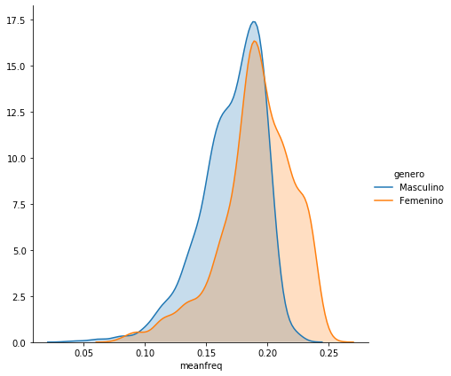

```python
poder_predictivo_numerica(datos,"meanfreq","genero")
```

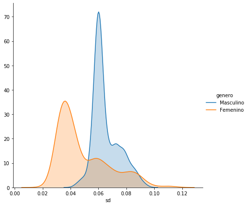

```python
poder_predictivo_numerica(datos,"sd","genero")
```

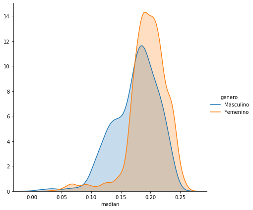

```python
poder_predictivo_numerica(datos,"median","genero")
```

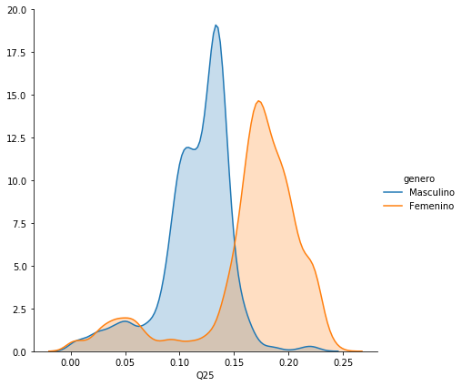

```python
poder_predictivo_numerica(datos,"Q25","genero")
```

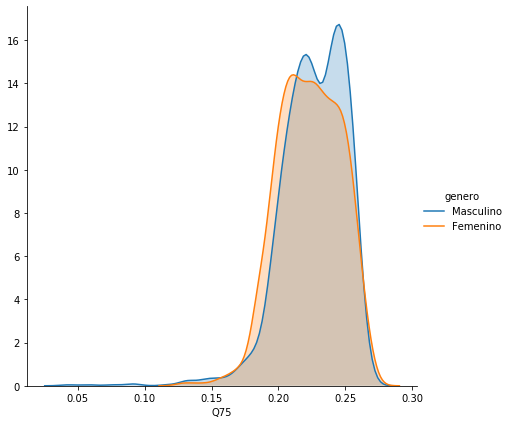

```python
poder_predictivo_numerica(datos,"Q75","genero")
```

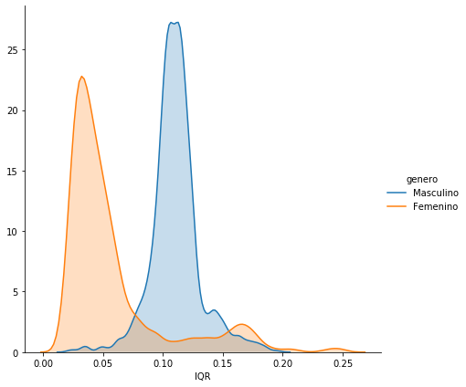

```python
poder_predictivo_numerica(datos,"IQR","genero")
```

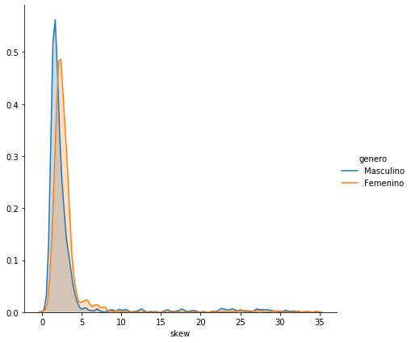

```python
poder_predictivo_numerica(datos,"skew","genero")
```

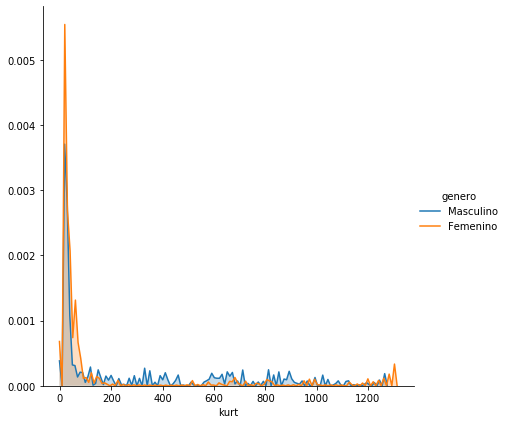

```python
poder_predictivo_numerica(datos,"kurt","genero")
```

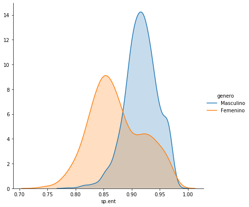

```python
poder_predictivo_numerica(datos,"sp.ent","genero")
```

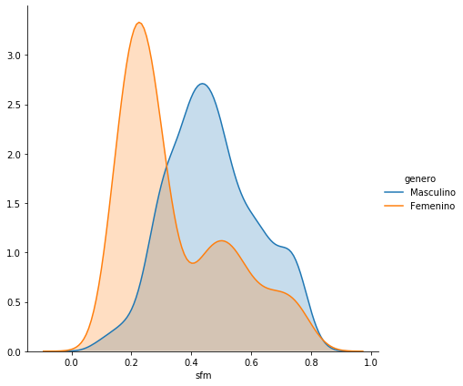

```python
poder_predictivo_numerica(datos,"sfm","genero")
```

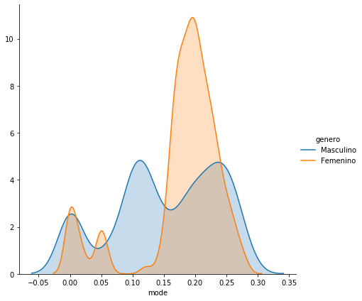

```python
poder_predictivo_numerica(datos,"mode","genero")
```

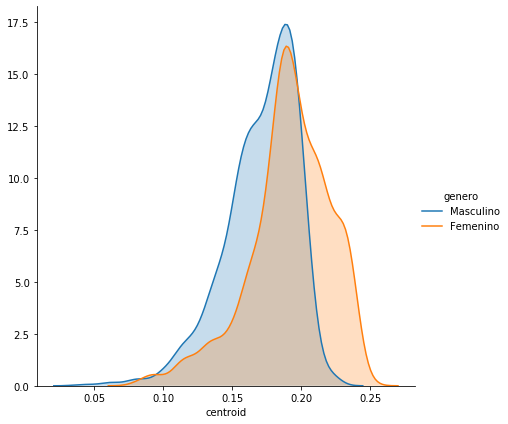

```python
poder_predictivo_numerica(datos,"centroid","genero")
```

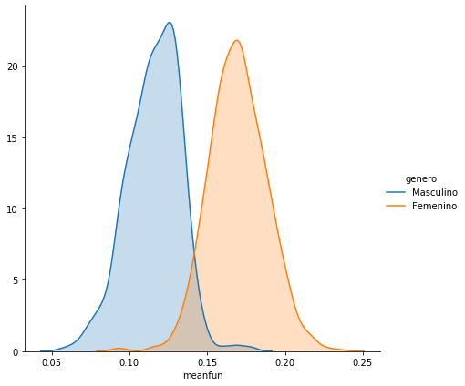

```python
poder_predictivo_numerica(datos,"meanfun","genero")
```

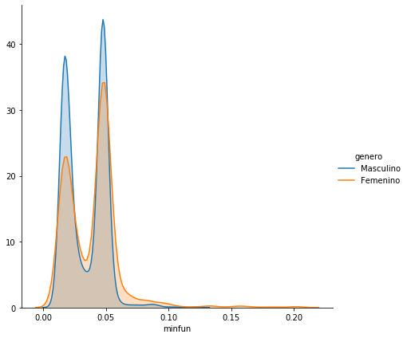

```python
poder_predictivo_numerica(datos,"minfun","genero")
```

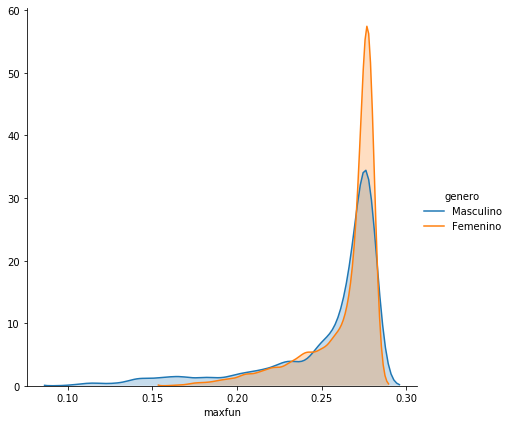

```python
poder_predictivo_numerica(datos,"maxfun","genero")
```

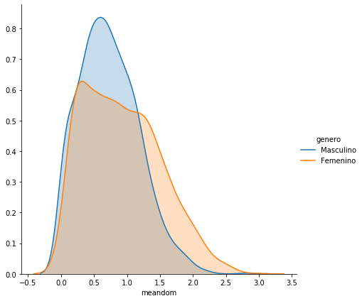

```python
poder_predictivo_numerica(datos,"meandom","genero")
```

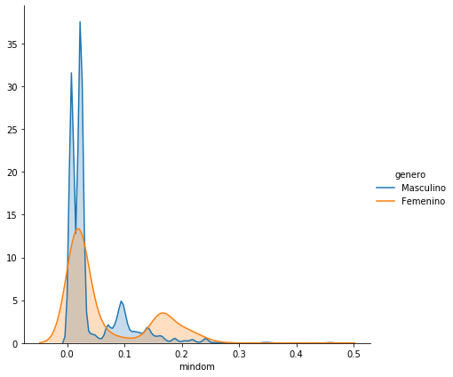

```python
poder_predictivo_numerica(datos,"mindom","genero")
```

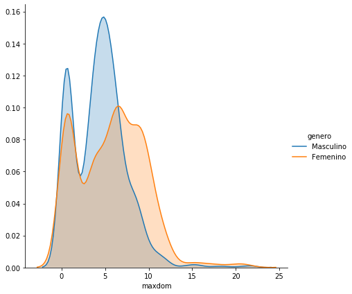

```python
poder_predictivo_numerica(datos,"maxdom","genero")
```

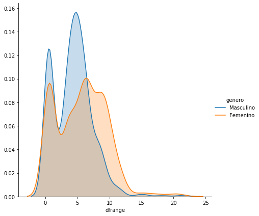

```python
poder_predictivo_numerica(datos,"dfrange","genero")
```

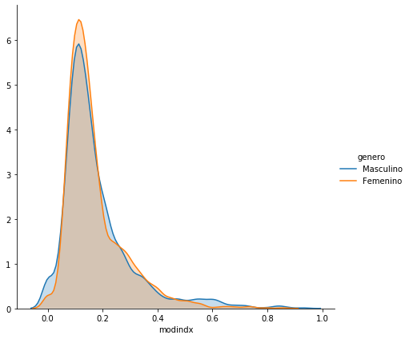

```python
poder_predictivo_numerica(datos,"modindx","genero")
```

```python
X = datos.iloc[:,[1,3,5,8,9,12]]
print(X.head())
y = datos.iloc[:,20:21]
print(y.head())

X_train, X_test, y_train, y_test = train_test_split(X, y, train_size=0.8, random_state=0)
```

```
         sd       Q25       IQR    sp.ent       sfm   meanfun
0  0.064241  0.015071  0.075122  0.893369  0.491918  0.084279
1  0.067310  0.019414  0.073252  0.892193  0.513724  0.107937
2  0.083829  0.008701  0.123207  0.846389  0.478905  0.098706
3  0.072111  0.096582  0.111374  0.963322  0.727232  0.088965
4  0.079146  0.078720  0.127325  0.971955  0.783568  0.106398
      genero
0  Masculino
1  Masculino
2  Masculino
3  Masculino
4  Masculino
```

```python
instancia_svm = SVC()
print(instancia_svm)
```

```
SVC(C=1.0, break_ties=False, cache_size=200, class_weight=None, coef0=0.0,
    decision_function_shape='ovr', degree=3, gamma='scale', kernel='rbf',
    max_iter=-1, probability=False, random_state=None, shrinking=True,
    tol=0.001, verbose=False)
```

```python
instancia_svm.fit(X_train,y_train.iloc[:,0].values)
prediccion = instancia_svm.predict(X_test)
MC = confusion_matrix(y_test, prediccion)
indices = indices_general_extra(MC,list(np.unique(y)))
for k in indices:
    print("\n%s:\n%s"%(k,str(indices[k])))
```

```
Matriz de Confusión:
[[281  20]
 [  6 327]]

Precisión Global:
0.9589905362776026

Error Global:
0.04100946372239744

Precisión por categoría:
   Femenino  Masculino
0  0.933555   0.981982

Precision Positiva (PP):
0.9819819819819819

Precision Negativa (PN):
0.9335548172757475

Falsos Positivos(FP):
0.06644518272425248

Falsos Negativos (FN):
0.018018018018018056

Asertividad Positiva (AP):
0.9423631123919308

Asertividad Negativa (NP):
0.9790940766550522
```

Para la siguiente combinacion se emplea la mejor combinacion para el algortmo de bosques que habia mejorado sustancialmente la precision, la combinacion de: meanfun, IQR, Q25, sd, sp.ent, centroid

```python
X = datos.iloc[:,[1,3,5,8,11,12]]
print(X.head())
y = datos.iloc[:,20:21]
print(y.head())

X_train, X_test, y_train, y_test = train_test_split(X, y, train_size=0.8, random_state=0)
```

```
         sd       Q25       IQR    sp.ent  centroid   meanfun
0  0.064241  0.015071  0.075122  0.893369  0.059781  0.084279
1  0.067310  0.019414  0.073252  0.892193  0.066009  0.107937
2  0.083829  0.008701  0.123207  0.846389  0.077316  0.098706
3  0.072111  0.096582  0.111374  0.963322  0.151228  0.088965
4  0.079146  0.078720  0.127325  0.971955  0.135120  0.106398
      genero
0  Masculino
1  Masculino
2  Masculino
3  Masculino
4  Masculino
```

```python
instancia_svm = SVC()
print(instancia_svm)
```

```
SVC(C=1.0, break_ties=False, cache_size=200, class_weight=None, coef0=0.0,
    decision_function_shape='ovr', degree=3, gamma='scale', kernel='rbf',
    max_iter=-1, probability=False, random_state=None, shrinking=True,
    tol=0.001, verbose=False)
```

```python
instancia_svm.fit(X_train,y_train.iloc[:,0].values)
prediccion = instancia_svm.predict(X_test)
MC = confusion_matrix(y_test, prediccion)
indices = indices_general_extra(MC,list(np.unique(y)))
for k in indices:
    print("\n%s:\n%s"%(k,str(indices[k])))
```

```
Matriz de Confusión:
[[283  18]
 [  6 327]]

Precisión Global:
0.9621451104100947

Error Global:
0.03785488958990535

Precisión por categoría:
   Femenino  Masculino
0  0.940199   0.981982

Precision Positiva (PP):
0.9819819819819819

Precision Negativa (PN):
0.9401993355481728

Falsos Positivos(FP):
0.05980066445182719

Falsos Negativos (FN):
0.018018018018018056

Asertividad Positiva (AP):
0.9478260869565217

Asertividad Negativa (NP):
0.9792387543252595
```

```python
A = np.matrix([[0.7413249211356467, 0.25867507886435326, 0.7717717717717718, 0.707641196013289, 0.292358803986711, 0.2282282282282282, 0.744927536231884, 0.7370242214532872],
               [0.9794952681388013, 0.02050473186119872, 0.975975975975976, 0.9833887043189369, 0.01661129568106312, 0.024024024024024038, 0.9848484848484849, 0.9736842105263158],
              [0.9605678233438486, 0.039432176656151396, 0.963963963963964, 0.9568106312292359, 0.04318936877076407, 0.036036036036036, 0.9610778443113772, 0.96],
              [0.944794952681388, 0.05520504731861198, 0.948948948948949, 0.9401993355481728, 0.05980066445182719, 0.05105105105105101, 0.9461077844311377, 0.9433333333333334],
              [0.9006309148264984, 0.09936908517350163, 0.9519519519519519, 0.8438538205980066, 0.15614617940199338, 0.048048048048048075, 0.8708791208791209, 0.9407407407407408],
              [0.9668769716088328, 0.03312302839116721, 0.960960960960961, 0.973421926910299, 0.02657807308970095, 0.03903903903903905, 0.975609756097561, 0.9575163398692811],
              [0.944794952681388, 0.05520504731861198, 0.948948948948949, 0.9401993355481728, 0.05980066445182719, 0.05105105105105101, 0.9461077844311377, 0.9433333333333334],
              [0.916403785488959, 0.08359621451104104, 0.987987987987988, 0.8372093023255814, 0.16279069767441856, 0.012012012012011963, 0.8703703703703703, 0.984375],
              [0.9810725552050473, 0.018927444794952675, 0.975975975975976, 0.9867109634551495, 0.013289036544850474, 0.024024024024024038, 0.9878419452887538, 0.9737704918032787],
              [0.9779179810725552, 0.02208201892744477, 0.9819819819819819, 0.973421926910299, 0.02657807308970095, 0.018018018018018056, 0.9761194029850746, 0.979933110367893],
              [0.9652996845425867, 0.034700315457413256, 0.987987987987988, 0.9401993355481728, 0.05980066445182719, 0.012012012012011963, 0.9481268011527377, 0.9860627177700348],
              [0.9542586750788643, 0.045741324921135695, 0.975975975975976, 0.9302325581395349, 0.06976744186046513, 0.024024024024024038, 0.9393063583815029, 0.9722222222222222],
              [0.9621451104100947, 0.03785488958990535, 0.9429429429429429, 0.9833887043189369, 0.01661129568106312, 0.0570570570570571, 0.9843260188087775, 0.9396825396825397],
              [0.9589905362776026, 0.04100946372239744, 0.987987987987988, 0.9269102990033222, 0.07308970099667778, 0.012012012012011963, 0.9373219373219374, 0.9858657243816255],
              [0.9810725552050473, 0.018927444794952675, 0.975975975975976, 0.9867109634551495, 0.013289036544850474, 0.024024024024024038, 0.9878419452887538, 0.9737704918032787],
              [0.9684542586750788, 0.03154574132492116, 0.975975975975976, 0.9601328903654485, 0.039867109634551534, 0.024024024024024038, 0.9643916913946587, 0.9730639730639731],
              [0.9574132492113565, 0.04258675078864349, 0.9669669669669669, 0.946843853820598, 0.05315614617940201, 0.033033033033033066, 0.9526627218934911, 0.9628378378378378],
              [0.9826498422712934, 0.017350157728706628, 0.9819819819819819, 0.9833887043189369, 0.01661129568106312, 0.018018018018018056, 0.9849397590361446, 0.9801324503311258],
              [0.9652996845425867, 0.034700315457413256, 0.96996996996997, 0.9601328903654485, 0.039867109634551534, 0.03003003003003002, 0.9641791044776119, 0.9665551839464883],
              [0.9637223974763407, 0.0362776025236593, 0.9819819819819819, 0.9435215946843853, 0.056478405315614655, 0.018018018018018056, 0.9505813953488372, 0.9793103448275862],
              [0.9779179810725552, 0.02208201892744477, 0.978978978978979, 0.9767441860465116, 0.023255813953488413, 0.02102102102102099, 0.978978978978979, 0.9767441860465116],
              [0.973186119873817, 0.02681388012618302, 0.972972972972973, 0.973421926910299, 0.02657807308970095, 0.027027027027026973, 0.9759036144578314, 0.9701986754966887],
              [0.9652996845425867, 0.034700315457413256, 0.987987987987988, 0.9401993355481728, 0.05980066445182719, 0.012012012012011963, 0.9481268011527377, 0.9860627177700348],
              [0.9779179810725552, 0.02208201892744477, 0.975975975975976, 0.9800664451827242, 0.019933554817275767, 0.024024024024024038, 0.9818731117824774, 0.9735973597359736],
              [0.9652996845425867, 0.034700315457413256, 0.963963963963964, 0.9667774086378738, 0.03322259136212624, 0.036036036036036, 0.9697885196374623, 0.9603960396039604],
              [0.9716088328075709, 0.028391167192429068, 0.975975975975976, 0.9667774086378738, 0.03322259136212624, 0.024024024024024038, 0.9701492537313433, 0.9732441471571907],
              [0.6798107255520505, 0.32018927444794953, 0.7807807807807807, 0.5681063122923588, 0.43189368770764125, 0.21921921921921927, 0.6666666666666666, 0.7008196721311475],
              [0.9242902208201893, 0.0757097791798107, 0.984984984984985, 0.8571428571428571, 0.1428571428571429, 0.01501501501501501, 0.8840970350404312, 0.9809885931558935],
              [0.9589905362776026, 0.04100946372239744, 0.9819819819819819, 0.9335548172757475, 0.06644518272425248, 0.018018018018018056, 0.9423631123919308, 0.9790940766550522],
              [0.9621451104100947, 0.03785488958990535, 0.9819819819819819, 0.9401993355481728, 0.05980066445182719, 0.018018018018018056, 0.9478260869565217, 0.9792387543252595]])
mi_df = pd.DataFrame(A)
nombres_filas = ["K-vecinos todas variables","K-vecinos 6 variables","Arbol de Decision (default)","Arbol de Decision (criterion='entropy',max_depth=2)","Arbol de Decision (criterion='gini', splitter='random', max_depth=3)",
                 "Arbol de Decision 6 predictoras (default)","Arbol de Decision 6 predictoras (criterion='entropy',max_depth=2)","Arbol de Decision 6 predictoras (criterion='gini', splitter='random', max_depth=3)",
                 "Bosques", "XGBoosting", "ADA Boosting", "Bosques (n_estimators=7, max_depth=2, random_state=0) ", "XGBoosting(n_estimators=7, max_depth=2, random_state=0)", "ADA Boosting (n_estimators=7, random_state=0)",
                 "Bosques 6 predictoras (opcion 1)", "XGBoosting 6 predictoras (opcion 1)", "ADA Boosting 6 predictoras(opcion 1)",
                 "Bosques 6 predictoras (opcion 1)(n_estimators=700, max_depth=200, random_state=0)", "XGBoosting 6 predictoras (opcion 1)(n_estimators=700, max_depth=200, random_state=0)", "ADA Boosting 6 predictoras(opcion 1)(n_estimators=700, random_state=0)",
                 "Bosques 6 predictoras (opcion 2)", "XGBoosting 6 predictoras (opcion 2)", "ADA Boosting 6 predictoras(opcion 2)",
                 "Bosques 6 predictoras (opcion 2)(n_estimators=700, max_depth=200, random_state=0)", "XGBoosting 6 predictoras (opcion 2)(n_estimators=700, max_depth=200, random_state=0)", "ADA Boosting 6 predictoras(opcion 2)(n_estimators=700, random_state=0)",
                 "SVM", "SVM linear", "SVM 6 predictoras (Opcion 1)", "SVM (Opcion 2)"]
nombres_columnas = ["Precisi´on Global","Error Global","Precisi´on Positiva (PP)", "Precisi´on Negativa (PN)", "Falsos Positivos (FP)", "Falsos Negativos (FN)", "Asertividad Positiva (AP)", "Asertividad Negativa (AN)"]
mi_df = pd.DataFrame(A, index = nombres_filas, columns = nombres_columnas )
mi_df
```

|  | Precisi´on Global | Error Global | Precisi´on Positiva (PP) | Precisi´on Negativa (PN) | Falsos Positivos (FP) | Falsos Negativos (FN) | Asertividad Positiva (AP) | Asertividad Negativa (AN) |
| --- | --- | --- | --- | --- | --- | --- | --- | --- |
| K-vecinos todas variables | 0.741325 | 0.258675 | 0.771772 | 0.707641 | 0.292359 | 0.228228 | 0.744928 | 0.737024 |
| K-vecinos 6 variables | 0.979495 | 0.020505 | 0.975976 | 0.983389 | 0.016611 | 0.024024 | 0.984848 | 0.973684 |
| Arbol de Decision (default) | 0.960568 | 0.039432 | 0.963964 | 0.956811 | 0.043189 | 0.036036 | 0.961078 | 0.960000 |
| Arbol de Decision (criterion='entropy',max_depth=2) | 0.944795 | 0.055205 | 0.948949 | 0.940199 | 0.059801 | 0.051051 | 0.946108 | 0.943333 |
| Arbol de Decision (criterion='gini', splitter='random', max_depth=3) | 0.900631 | 0.099369 | 0.951952 | 0.843854 | 0.156146 | 0.048048 | 0.870879 | 0.940741 |
| Arbol de Decision 6 predictoras (default) | 0.966877 | 0.033123 | 0.960961 | 0.973422 | 0.026578 | 0.039039 | 0.975610 | 0.957516 |
| Arbol de Decision 6 predictoras (criterion='entropy',max_depth=2) | 0.944795 | 0.055205 | 0.948949 | 0.940199 | 0.059801 | 0.051051 | 0.946108 | 0.943333 |
| Arbol de Decision 6 predictoras (criterion='gini', splitter='random', max_depth=3) | 0.916404 | 0.083596 | 0.987988 | 0.837209 | 0.162791 | 0.012012 | 0.870370 | 0.984375 |
| Bosques | 0.981073 | 0.018927 | 0.975976 | 0.986711 | 0.013289 | 0.024024 | 0.987842 | 0.973770 |
| XGBoosting | 0.977918 | 0.022082 | 0.981982 | 0.973422 | 0.026578 | 0.018018 | 0.976119 | 0.979933 |
| ADA Boosting | 0.965300 | 0.034700 | 0.987988 | 0.940199 | 0.059801 | 0.012012 | 0.948127 | 0.986063 |
| Bosques (n_estimators=7, max_depth=2, random_state=0) | 0.954259 | 0.045741 | 0.975976 | 0.930233 | 0.069767 | 0.024024 | 0.939306 | 0.972222 |
| XGBoosting(n_estimators=7, max_depth=2, random_state=0) | 0.962145 | 0.037855 | 0.942943 | 0.983389 | 0.016611 | 0.057057 | 0.984326 | 0.939683 |
| ADA Boosting (n_estimators=7, random_state=0) | 0.958991 | 0.041009 | 0.987988 | 0.926910 | 0.073090 | 0.012012 | 0.937322 | 0.985866 |
| Bosques 6 predictoras (opcion 1) | 0.981073 | 0.018927 | 0.975976 | 0.986711 | 0.013289 | 0.024024 | 0.987842 | 0.973770 |
| XGBoosting 6 predictoras (opcion 1) | 0.968454 | 0.031546 | 0.975976 | 0.960133 | 0.039867 | 0.024024 | 0.964392 | 0.973064 |
| ADA Boosting 6 predictoras(opcion 1) | 0.957413 | 0.042587 | 0.966967 | 0.946844 | 0.053156 | 0.033033 | 0.952663 | 0.962838 |
| Bosques 6 predictoras (opcion 1)(n_estimators=700, max_depth=200, random_state=0) | 0.982650 | 0.017350 | 0.981982 | 0.983389 | 0.016611 | 0.018018 | 0.984940 | 0.980132 |
| XGBoosting 6 predictoras (opcion 1)(n_estimators=700, max_depth=200, random_state=0) | 0.965300 | 0.034700 | 0.969970 | 0.960133 | 0.039867 | 0.030030 | 0.964179 | 0.966555 |
| ADA Boosting 6 predictoras(opcion 1)(n_estimators=700, random_state=0) | 0.963722 | 0.036278 | 0.981982 | 0.943522 | 0.056478 | 0.018018 | 0.950581 | 0.979310 |
| Bosques 6 predictoras (opcion 2) | 0.977918 | 0.022082 | 0.978979 | 0.976744 | 0.023256 | 0.021021 | 0.978979 | 0.976744 |
| XGBoosting 6 predictoras (opcion 2) | 0.973186 | 0.026814 | 0.972973 | 0.973422 | 0.026578 | 0.027027 | 0.975904 | 0.970199 |
| ADA Boosting 6 predictoras(opcion 2) | 0.965300 | 0.034700 | 0.987988 | 0.940199 | 0.059801 | 0.012012 | 0.948127 | 0.986063 |
| Bosques 6 predictoras (opcion 2)(n_estimators=700, max_depth=200, random_state=0) | 0.977918 | 0.022082 | 0.975976 | 0.980066 | 0.019934 | 0.024024 | 0.981873 | 0.973597 |
| XGBoosting 6 predictoras (opcion 2)(n_estimators=700, max_depth=200, random_state=0) | 0.965300 | 0.034700 | 0.963964 | 0.966777 | 0.033223 | 0.036036 | 0.969789 | 0.960396 |
| ADA Boosting 6 predictoras(opcion 2)(n_estimators=700, random_state=0) | 0.971609 | 0.028391 | 0.975976 | 0.966777 | 0.033223 | 0.024024 | 0.970149 | 0.973244 |
| SVM | 0.679811 | 0.320189 | 0.780781 | 0.568106 | 0.431894 | 0.219219 | 0.666667 | 0.700820 |
| SVM linear | 0.924290 | 0.075710 | 0.984985 | 0.857143 | 0.142857 | 0.015015 | 0.884097 | 0.980989 |
| SVM 6 predictoras (Opcion 1) | 0.958991 | 0.041009 | 0.981982 | 0.933555 | 0.066445 | 0.018018 | 0.942363 | 0.979094 |
| SVM (Opcion 2) | 0.962145 | 0.037855 | 0.981982 | 0.940199 | 0.059801 | 0.018018 | 0.947826 | 0.979239 |

Con la combinacion de 6 predictoras el SVM mejora sustancialmente su precision global en ambos casos. A pesar de ello, no logra acercarse tanto a los modelos con mejor precision. El modelo que emplea Bosques con seis predictoras se desempena como el mejor con una precision superior a 98% que tambien cumplen otros modelos.

Ejercicio 2: [35 puntos] Esta pregunta utiliza los datos (tumores.csv). Se trata de un conjunto de datos de caracter´ısticas del tumor cerebral que incluye cinco variables de primer orden y ocho de textura y cuatro par´ametros de evaluaci´on de la calidad con el nivel objetivo. La variables son: Media, Varianza, Desviaci´on est´andar, Asimetr´ıa, Kurtosis, Contraste, Energ´ıa, ASM (segundo momento angular), Entrop´ıa, Homogeneidad, Disimilitud, Correlaci´on, Grosor, PSNR (Pico de la relaci´on se˜nal-ruido), SSIM (´Indice de Similitud Estructurada), MSE (Mean Square Error), DC (Coeficiente de Dados) y la variable a predecir tipo (1 = Tumor, 0 =No-Tumor). Realice lo siguiente:

1. Use M´aquinas de Soporte Vectorial en Python para generar un modelo predictivo para la tabla tumores.csv usando el 70 % de los datos para la tabla aprendizaje y un 30 % para la tabla testing.

```python
pasada = os.getcwd()
os.chdir("C:/Users/rzamoram/OneDrive - Intel Corporation/Documents/Machine Learning/Métodos Supervisados con Python/Clase 01")
print(os.getcwd())
datos = pd.read_csv('tumores.csv',delimiter=',',decimal=".")
datos['imagen'] = datos['imagen'].astype('category')
print(datos.shape)
print(datos.head())
print(datos.info())
```

```
C:\Users\rzamoram\OneDrive - Intel Corporation\Documents\Machine Learning\Métodos Supervisados con Python\Clase 01
(1275, 18)
   imagen      media     varianza  desviacion.estandar  entropia  asimetria  \
0  Image1  23.448517  2538.985627            50.388348  0.651174   1.984202
1  Image2   4.398331   834.853030            28.893823  0.953532   6.495203
2  Image3   3.244263   642.059166            25.338886  0.966065   7.772860
3  Image4   8.511353  1126.214187            33.559115  0.868765   3.763142
4  Image5  21.000793  2235.316978            47.279139  0.684724   1.936029

    kurtosis   contraste   energia       asm  homogeneidad  disiminitud  \
0   5.421042  181.467713  0.781557  0.610831      0.847033     2.765411
1  43.349355   76.745886  0.972770  0.946281      0.980762     0.548605
2  61.756034   81.752406  0.980161  0.960715      0.985066     0.540411
3  15.107579  362.291213  0.921786  0.849690      0.949295     2.765725
4   4.722343  312.439226  0.804184  0.646711      0.880301     3.006660

   correlacion        psnr      ssim       mse        dc  tipo
0     0.968576   97.974630  0.777011  0.171163  0.303989     1
1     0.959751  110.346597  0.977953  0.009913  0.839019     1
2     0.944259  112.266298  0.985362  0.006372  0.849775     1
3     0.859027  101.955792  0.881015  0.068437  0.000000     0
4     0.938572   97.639870  0.766308  0.184878  0.000000     0
<class 'pandas.core.frame.DataFrame'>
RangeIndex: 1275 entries, 0 to 1274
Data columns (total 18 columns):
 #   Column               Non-Null Count  Dtype
---  ------               --------------  -----
 0   imagen               1275 non-null   category
 1   media                1275 non-null   float64
 2   varianza             1275 non-null   float64
 3   desviacion.estandar  1275 non-null   float64
 4   entropia             1275 non-null   float64
 5   asimetria            1275 non-null   float64
 6   kurtosis             1275 non-null   float64
 7   contraste            1275 non-null   float64
 8   energia              1275 non-null   float64
 9   asm                  1275 non-null   float64
 10  homogeneidad         1275 non-null   float64
 11  disiminitud          1275 non-null   float64
 12  correlacion          1275 non-null   float64
 13  psnr                 1275 non-null   float64
 14  ssim                 1275 non-null   float64
 15  mse                  1275 non-null   float64
 16  dc                   1275 non-null   float64
 17  tipo                 1275 non-null   int64
dtypes: category(1), float64(16), int64(1)
memory usage: 221.9 KB
None
```

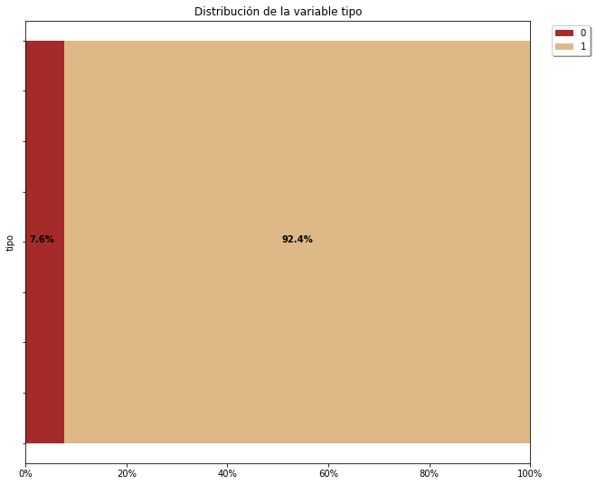

```python
distribucion_variable_predecir(datos,"tipo")
```

Ejercicio muy desbalanceado

```python
X = datos.iloc[:,1:17]
print(X.head())
y = datos.iloc[:,17:18]
print(y.head())
X_train, X_test, y_train, y_test = train_test_split(X, y, train_size=0.7, random_state=0)

instancia_svm = SVC()
print(instancia_svm)
```

```
       media     varianza  desviacion.estandar  entropia  asimetria  \
0  23.448517  2538.985627            50.388348  0.651174   1.984202
1   4.398331   834.853030            28.893823  0.953532   6.495203
2   3.244263   642.059166            25.338886  0.966065   7.772860
3   8.511353  1126.214187            33.559115  0.868765   3.763142
4  21.000793  2235.316978            47.279139  0.684724   1.936029

    kurtosis   contraste   energia       asm  homogeneidad  disiminitud  \
0   5.421042  181.467713  0.781557  0.610831      0.847033     2.765411
1  43.349355   76.745886  0.972770  0.946281      0.980762     0.548605
2  61.756034   81.752406  0.980161  0.960715      0.985066     0.540411
3  15.107579  362.291213  0.921786  0.849690      0.949295     2.765725
4   4.722343  312.439226  0.804184  0.646711      0.880301     3.006660

   correlacion        psnr      ssim       mse        dc
0     0.968576   97.974630  0.777011  0.171163  0.303989
1     0.959751  110.346597  0.977953  0.009913  0.839019
2     0.944259  112.266298  0.985362  0.006372  0.849775
3     0.859027  101.955792  0.881015  0.068437  0.000000
4     0.938572   97.639870  0.766308  0.184878  0.000000
   tipo
0     1
1     1
2     1
3     0
4     0
SVC(C=1.0, break_ties=False, cache_size=200, class_weight=None, coef0=0.0,
    decision_function_shape='ovr', degree=3, gamma='scale', kernel='rbf',
    max_iter=-1, probability=False, random_state=None, shrinking=True,
    tol=0.001, verbose=False)
```

```python
instancia_svm.fit(X_train,y_train.iloc[:,0].values)
print("Las predicciones en Testing son: {}".format(instancia_svm.predict(X_test)))
```

```
Las predicciones en Testing son: [1 1 1 1 1 1 1 1 1 1 1 1 1 1 1 1 1 1 1 1 1 1 1 1 1 1 1 1 1 1 1 1 1 1 1 1 1
 1 1 1 1 1 1 1 1 1 1 1 1 1 1 1 1 1 1 1 1 1 1 1 1 1 1 1 1 1 1 1 1 1 1 1 1 1
 1 1 1 1 1 1 1 1 1 1 1 1 1 1 1 1 1 1 1 1 1 1 1 1 1 1 1 1 1 1 1 1 1 1 1 1 1
 1 1 1 1 1 1 1 1 1 1 1 1 1 1 1 1 1 1 1 1 1 1 1 1 1 1 1 1 1 1 1 1 1 1 1 1 1
 1 1 1 1 1 1 1 1 1 1 1 1 1 1 1 1 1 1 1 1 1 1 1 1 1 1 1 1 1 1 1 1 1 1 1 1 1
 1 1 1 1 1 1 1 1 1 1 1 1 1 1 1 1 1 1 1 1 1 1 1 1 1 1 1 1 1 1 1 1 1 1 1 1 1
 1 1 1 1 1 1 1 1 1 1 1 1 1 1 1 1 1 1 1 1 1 1 1 1 1 1 1 1 1 1 1 1 1 1 1 1 1
 1 1 1 1 1 1 1 1 1 1 1 1 1 1 1 1 1 1 1 1 1 1 1 1 1 1 1 1 1 1 1 1 1 1 1 1 1
 1 1 1 1 1 1 1 1 1 1 1 1 1 1 1 1 1 1 1 1 1 1 1 1 1 1 1 1 1 1 1 1 1 1 1 1 1
 1 1 1 1 1 1 1 1 1 1 1 1 1 1 1 1 1 1 1 1 1 1 1 1 1 1 1 1 1 1 1 1 1 1 1 1 1
 1 1 1 1 1 1 1 1 1 1 1 1 1]
```

```python
prediccion = instancia_svm.predict(X_test)
MC = confusion_matrix(y_test, prediccion)
indices = indices_general(MC,list(np.unique(y)))
for k in indices:
    print("\n%s:\n%s"%(k,str(indices[k])))
```

```
Matriz de Confusión:
[[  0  33]
 [  0 350]]

Precisión Global:
0.9138381201044387

Error Global:
0.08616187989556134

Precisión por categoría:
     0    1
0  0.0  1.0
```

1. Usando la funci´on programada en el ejercicio 1 de la tarea anterior, los datos tumores.csv y los modelos generados arriba construya un DataFrame de manera que en cada una de las filas aparezca un modelo predictivo y en las columnas aparezcan los ´ındices Precisi´on Global, Error Global Precisi´on Positiva (PP), Precisi´on Negativa (PN), Falsos Positivos (FP), los Falsos Negativos (FN), la Asertividad Positiva (AP) y la Asertividad Negativa (AN). Compare los resultados con todos los modelos generados en las tareas antariores ¿Cu´al de los modelos es mejor para estos datos?

```python
indices = indices_general_extra(MC,list(np.unique(y)))
for k in indices:
    print("\n%s:\n%s"%(k,str(indices[k])))
```

```
Matriz de Confusión:
[[  0  33]
 [  0 350]]

Precisión Global:
0.9138381201044387

Error Global:
0.08616187989556134

Precisión por categoría:
     0    1
0  0.0  1.0

Precision Positiva (PP):
1.0

Precision Negativa (PN):
0.0

Falsos Positivos(FP):
1.0

Falsos Negativos (FN):
0.0

Asertividad Positiva (AP):
0.9138381201044387

Asertividad Negativa (NP):
nan
```

```python
A = np.matrix([[0.8981723237597912, 0.10182767624020883, 0.9742857142857143, 0.09090909090909091, 0.9090909090909091, 0.02571428571428569, 0.9191374663072777, 0.25],
               [0.9843342036553525, 0.015665796344647487, 0.9914285714285714, 0.9090909090909091, 0.09090909090909094, 0.008571428571428563, 0.9914285714285714, 0.9090909090909091],
               [0.9817232375979112, 0.018276762402088753, 0.9885714285714285, 0.9090909090909091, 0.09090909090909094, 0.011428571428571455, 0.9914040114613181, 0.8823529411764706],
               [0.9765013054830287, 0.023498694516971286, 0.9942857142857143, 0.7878787878787878, 0.21212121212121215, 0.005714285714285672, 0.9802816901408451, 0.9285714285714286],
               [0.9843342036553525, 0.015665796344647487, 0.9914285714285714, 0.9090909090909091, 0.09090909090909094, 0.008571428571428563, 0.9914285714285714, 0.9090909090909091],
               [0.9921671018276762, 0.007832898172323799, 0.9914285714285714, 1.0, 0.0, 0.008571428571428563, 1.0, 0.9166666666666666],
               [0.9843342036553525, 0.015665796344647487, 0.9914285714285714, 0.9090909090909091, 0.09090909090909094, 0.008571428571428563, 0.9914285714285714, 0.9090909090909091],
               [0.9869451697127938, 0.01305483028720622, 0.9914285714285714, 0.9393939393939394, 0.06060606060606055, 0.008571428571428563, 0.994269340974212, 0.9117647058823529],
               [0.9138381201044387, 0.08616187989556134, 1.0, 0.0, 1.0, 0.0, 0.9138381201044387, 0]])
mi_df = pd.DataFrame(A)
nombres_filas = ["K-vecinos", "Arbol de Decision", "Bosques aleatorios", "XGBoosting", "ADA Boosting",
                 "Bosques aleatorios (n_estimators=1000, max_depth=250, random_state=0)",
                 "XGBoosting (n_estimators=1000, max_depth=250, random_state=0)",
                 "ADA Boosting (n_estimators=1000, random_state=0)", "SVM"]
nombres_columnas = ["Precisi´on Global","Error Global","Precisi´on Positiva (PP)", "Precisi´on Negativa (PN)", "Falsos Positivos (FP)", "Falsos Negativos (FN)", "Asertividad Positiva (AP)", "Asertividad Negativa (AN)"]
mi_df = pd.DataFrame(A, index = nombres_filas, columns = nombres_columnas )
mi_df
```

|  | Precisi´on Global | Error Global | Precisi´on Positiva (PP) | Precisi´on Negativa (PN) | Falsos Positivos (FP) | Falsos Negativos (FN) | Asertividad Positiva (AP) | Asertividad Negativa (AN) |
| --- | --- | --- | --- | --- | --- | --- | --- | --- |
| K-vecinos | 0.898172 | 0.101828 | 0.974286 | 0.090909 | 0.909091 | 0.025714 | 0.919137 | 0.250000 |
| Arbol de Decision | 0.984334 | 0.015666 | 0.991429 | 0.909091 | 0.090909 | 0.008571 | 0.991429 | 0.909091 |
| Bosques aleatorios | 0.981723 | 0.018277 | 0.988571 | 0.909091 | 0.090909 | 0.011429 | 0.991404 | 0.882353 |
| XGBoosting | 0.976501 | 0.023499 | 0.994286 | 0.787879 | 0.212121 | 0.005714 | 0.980282 | 0.928571 |
| ADA Boosting | 0.984334 | 0.015666 | 0.991429 | 0.909091 | 0.090909 | 0.008571 | 0.991429 | 0.909091 |
| Bosques aleatorios (n_estimators=1000, max_depth=250, random_state=0) | 0.992167 | 0.007833 | 0.991429 | 1.000000 | 0.000000 | 0.008571 | 1.000000 | 0.916667 |
| XGBoosting (n_estimators=1000, max_depth=250, random_state=0) | 0.984334 | 0.015666 | 0.991429 | 0.909091 | 0.090909 | 0.008571 | 0.991429 | 0.909091 |
| ADA Boosting (n_estimators=1000, random_state=0) | 0.986945 | 0.013055 | 0.991429 | 0.939394 | 0.060606 | 0.008571 | 0.994269 | 0.911765 |
| SVM | 0.913838 | 0.086162 | 1.000000 | 0.000000 | 1.000000 | 0.000000 | 0.913838 | 0.000000 |

Para este ejercicio el mejor resulta ser bosques aleatorios, especificamente cambiando los parametros dando un estimador de 1000 con una profundidad de 250, el metodo de Bosques aleatorios arroja una precision global de 0.992167 que lo convierte en la prediccion mas acertada. El SVM en realidad tiene el segundo peor desmpeno, de hecho como modelo tiene un problema muy serio, no identifica los no tumores.

1. Repita los ejercicios 1-2, vez use otro n´ucleo (Kernel). ¿Mejora la predicci´on?

```python
instancia_svm = SVC(kernel='linear')
print(instancia_svm)
```

```
SVC(C=1.0, break_ties=False, cache_size=200, class_weight=None, coef0=0.0,
    decision_function_shape='ovr', degree=3, gamma='scale', kernel='linear',
    max_iter=-1, probability=False, random_state=None, shrinking=True,
    tol=0.001, verbose=False)
```

```python
instancia_svm.fit(X_train,y_train.iloc[:,0].values)
prediccion = instancia_svm.predict(X_test)
MC = confusion_matrix(y_test, prediccion)
indices = indices_general(MC,list(np.unique(y)))
for k in indices:
    print("\n%s:\n%s"%(k,str(indices[k])))
```

```
Matriz de Confusión:
[[ 15  18]
 [  7 343]]

Precisión Global:
0.9347258485639687

Error Global:
0.06527415143603132

Precisión por categoría:
          0     1
0  0.454545  0.98
```

```python
indices = indices_general_extra(MC,list(np.unique(y)))
for k in indices:
    print("\n%s:\n%s"%(k,str(indices[k])))
```

```
Matriz de Confusión:
[[ 15  18]
 [  7 343]]

Precisión Global:
0.9347258485639687

Error Global:
0.06527415143603132

Precisión por categoría:
          0     1
0  0.454545  0.98

Precision Positiva (PP):
0.98

Precision Negativa (PN):
0.45454545454545453

Falsos Positivos(FP):
0.5454545454545454

Falsos Negativos (FN):
0.020000000000000018

Asertividad Positiva (AP):
0.9501385041551247

Asertividad Negativa (NP):
0.6818181818181818
```

```python
A = np.matrix([[0.8981723237597912, 0.10182767624020883, 0.9742857142857143, 0.09090909090909091, 0.9090909090909091, 0.02571428571428569, 0.9191374663072777, 0.25],
               [0.9843342036553525, 0.015665796344647487, 0.9914285714285714, 0.9090909090909091, 0.09090909090909094, 0.008571428571428563, 0.9914285714285714, 0.9090909090909091],
               [0.9817232375979112, 0.018276762402088753, 0.9885714285714285, 0.9090909090909091, 0.09090909090909094, 0.011428571428571455, 0.9914040114613181, 0.8823529411764706],
               [0.9765013054830287, 0.023498694516971286, 0.9942857142857143, 0.7878787878787878, 0.21212121212121215, 0.005714285714285672, 0.9802816901408451, 0.9285714285714286],
               [0.9843342036553525, 0.015665796344647487, 0.9914285714285714, 0.9090909090909091, 0.09090909090909094, 0.008571428571428563, 0.9914285714285714, 0.9090909090909091],
               [0.9921671018276762, 0.007832898172323799, 0.9914285714285714, 1.0, 0.0, 0.008571428571428563, 1.0, 0.9166666666666666],
               [0.9843342036553525, 0.015665796344647487, 0.9914285714285714, 0.9090909090909091, 0.09090909090909094, 0.008571428571428563, 0.9914285714285714, 0.9090909090909091],
               [0.9869451697127938, 0.01305483028720622, 0.9914285714285714, 0.9393939393939394, 0.06060606060606055, 0.008571428571428563, 0.994269340974212, 0.9117647058823529],
               [0.9138381201044387, 0.08616187989556134, 1.0, 0.0, 1.0, 0.0, 0.9138381201044387, 0],
               [0.9347258485639687, 0.06527415143603132, 0.98, 0.45454545454545453, 0.5454545454545454, 0.020000000000000018, 0.9501385041551247, 0.6818181818181818]])
mi_df = pd.DataFrame(A)
nombres_filas = ["K-vecinos", "Arbol de Decision", "Bosques aleatorios", "XGBoosting", "ADA Boosting",
                 "Bosques aleatorios (n_estimators=1000, max_depth=250, random_state=0)",
                 "XGBoosting (n_estimators=1000, max_depth=250, random_state=0)",
                 "ADA Boosting (n_estimators=1000, random_state=0)", "SVM", "SVM Linear"]
nombres_columnas = ["Precisi´on Global","Error Global","Precisi´on Positiva (PP)", "Precisi´on Negativa (PN)", "Falsos Positivos (FP)", "Falsos Negativos (FN)", "Asertividad Positiva (AP)", "Asertividad Negativa (AN)"]
mi_df = pd.DataFrame(A, index = nombres_filas, columns = nombres_columnas )
mi_df
```

|  | Precisi´on Global | Error Global | Precisi´on Positiva (PP) | Precisi´on Negativa (PN) | Falsos Positivos (FP) | Falsos Negativos (FN) | Asertividad Positiva (AP) | Asertividad Negativa (AN) |
| --- | --- | --- | --- | --- | --- | --- | --- | --- |
| K-vecinos | 0.898172 | 0.101828 | 0.974286 | 0.090909 | 0.909091 | 0.025714 | 0.919137 | 0.250000 |
| Arbol de Decision | 0.984334 | 0.015666 | 0.991429 | 0.909091 | 0.090909 | 0.008571 | 0.991429 | 0.909091 |
| Bosques aleatorios | 0.981723 | 0.018277 | 0.988571 | 0.909091 | 0.090909 | 0.011429 | 0.991404 | 0.882353 |
| XGBoosting | 0.976501 | 0.023499 | 0.994286 | 0.787879 | 0.212121 | 0.005714 | 0.980282 | 0.928571 |
| ADA Boosting | 0.984334 | 0.015666 | 0.991429 | 0.909091 | 0.090909 | 0.008571 | 0.991429 | 0.909091 |
| Bosques aleatorios (n_estimators=1000, max_depth=250, random_state=0) | 0.992167 | 0.007833 | 0.991429 | 1.000000 | 0.000000 | 0.008571 | 1.000000 | 0.916667 |
| XGBoosting (n_estimators=1000, max_depth=250, random_state=0) | 0.984334 | 0.015666 | 0.991429 | 0.909091 | 0.090909 | 0.008571 | 0.991429 | 0.909091 |
| ADA Boosting (n_estimators=1000, random_state=0) | 0.986945 | 0.013055 | 0.991429 | 0.939394 | 0.060606 | 0.008571 | 0.994269 | 0.911765 |
| SVM | 0.913838 | 0.086162 | 1.000000 | 0.000000 | 1.000000 | 0.000000 | 0.913838 | 0.000000 |
| SVM Linear | 0.934726 | 0.065274 | 0.980000 | 0.454545 | 0.545455 | 0.020000 | 0.950139 | 0.681818 |

El SVM linear mejora un poco la estimacion, pero siguen estando dentro de la peor precision para estos datos, hay muchos datos confundidos para los no tumores en especial. Para este ejercicio el mejor resulta ser bosques aleatorios, especificamente cambiando los parametros dando un estimador de 1000 con una profundidad de 250, el metodo de Bosques aleatorios arroja una precision global de 0.992167 que lo convierte en la prediccion mas acertada.

1. Investigue sobre paquete en Python que permiten realizar graficaci´on en 3D. Escoja en que mejor considere para resolver los siguientes ejercicios.

```python
# modulos para graficar
from mpl_toolkits.mplot3d import Axes3D
import matplotlib.pyplot as plt
```

[figure not shown]

```python
fig = plt.figure()

ax = Axes3D(fig)

plt.show()
```

1. Dibuje con colores los puntos de ambas clases en R3. Deber´ıa verse algo similar a lo siguiente:

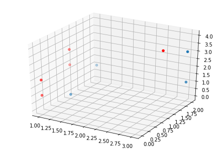

```python
from mpl_toolkits.mplot3d import axes3d
import matplotlib.pyplot as plt

fig = plt.figure()
ax = Axes3D(fig)

x = np.array([3,1,3,1])
y = np.array([2,2,2,1])
z = np.array([3,1,1,0])

x2 = np.array([1,1,1,3,1])
y2 = np.array([0,0,1,1,1])
z2 = np.array([1,2,2,4,3])

ax.scatter(x, y, z)
ax.scatter(x2, y2, z2, color='r')
plt.show()
```